# Metagenomics 2

Prof. Harbert

Meeting 10

# Kraken 2

Based on our testing Kraken 2 was a good balance of time and space efficiency. Today we will experiment with Kraken2 further by building a custom database to search against.

Guidance on using Kraken2 can be found in the [Manual](https://ccb.jhu.edu/software/kraken2/index.shtml?t=manual)

Also, the [Kraken2 paper](https://www.biorxiv.org/content/10.1101/762302v1) is a good resource that shows how Kraken2 performs relative to related programs.

## Custom DB: Plastid genomes

First, we must download the RefSeq plastid genomes database.

```bash
mkdir kraken
cd kraken

#1) Download Plastid reference data:
wget ftp://ftp.ncbi.nlm.nih.gov/refseq/release/plastid/plastid.1.1.genomic.fna.gz
wget ftp://ftp.ncbi.nlm.nih.gov/refseq/release/plastid/plastid.2.1.genomic.fna.gz
wget ftp://ftp.ncbi.nlm.nih.gov/refseq/release/plastid/plastid.3.1.genomic.fna.gz


#2) Then, these files need to be unzipped (uncompressed).

gunzip *.fna.gz

#3) Name your database
DBNAME='plastid_custom'

#4) Get the NCBI taxonomy files:
kraken2-build --download-taxonomy --db $DBNAME

#5) Add custom reference data
kraken2-build --add-to-library plastid.1.1.genomic.fna --db $DBNAME
kraken2-build --add-to-library plastid.2.1.genomic.fna --db $DBNAME
kraken2-build --add-to-library plastid.3.1.genomic.fna --db $DBNAME

#6) Finalize the database
kraken2-build --build --db $DBNAME
```

## Query the custom DB

Now we can test our custom database using our MATK eDNA sample file.

Recall that last time we queried the entire ‘nt’ database using:

```bash
kdb=/usr/share/data/krakendb/nt-custom/
targdata=/usr/share/data/BIO331/MATK-1RKIM/small/barcode11.s.fastq

kraken2 --db $kdb  --threads 1 --use-names --report kreport.tab $targdata > kraken.out
```

All we need to do is substitute the path to our custom database.

*Make sure working directory is set to the ‘kraken’ folder*

```bash
kdb=plastid_custom
targdata=/usr/share/data/BIO331/MATK-1RKIM/small/barcode11.s.fastq

kraken2 --db $kdb  --threads 1 --use-names --report kreport.tab $targdata > kraken.out
```

# Visualizing Kraken report files

TIP: Check out the quick-reference guide on [ggplot2 from RStudio](https://rstudio.com/wp-content/uploads/2015/03/ggplot2-cheatsheet.pdf)

```r
library(ggplot2)
library(taxonomizr)
kreport=read.delim('kraken/kreport.tab', sep ='\t', header=F)

#preview
head(kreport)
```

|  | V1 | V2 | V3 | V4 | V5 | V6 |
| --- | --- | --- | --- | --- | --- | --- |
| 1 | 84.54 | 35858 | 35858 | U | 0 | unclassified |
| 2 | 15.46 | 6555 | 0 | R | 1 | root |
| 3 | 15.46 | 6555 | 0 | R1 | 131567 | cellular organisms |
| 4 | 15.46 | 6555 | 0 | D | 2759 | Eukaryota |
| 5 | 15.44 | 6550 | 0 | K | 33090 | Viridiplantae |
| 6 | 15.44 | 6547 | 0 | P | 35493 | Streptophyta |

```r
#how many rows?
nrow(kreport)
```

```
## [1] 673
```

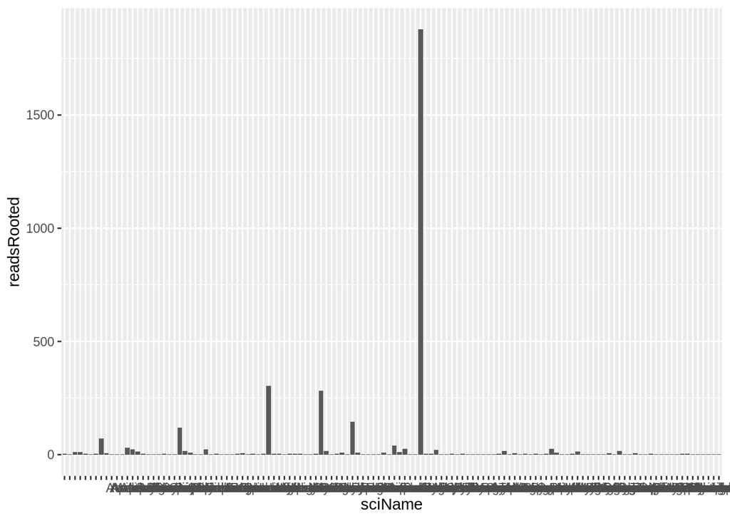

```r
#add column names to the kreport table
colnames(kreport) = c('percent', 'readsRooted', 'reads', 'taxRank', 'taxID', 'sciName')

fam.kreport = subset(kreport, kreport$taxRank=='F')

ggplot(data=fam.kreport) +
  geom_bar(aes(x=sciName, y = readsRooted), stat='identity')
```

How can we improve upon this graph? What other ways might we represent these data?

Try:

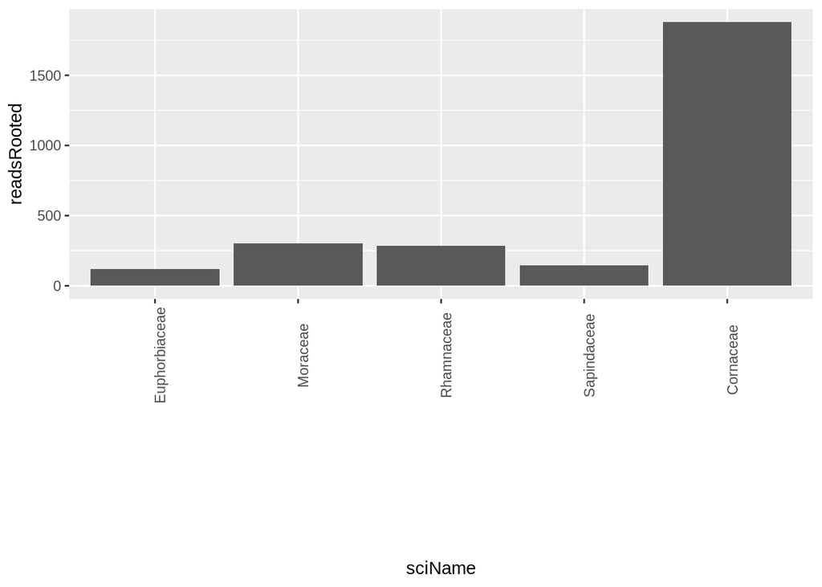

```r
x <- transform(fam.kreport, variable=reorder(sciName, -readsRooted) )
x = x[order(-x$readsRooted),]


ggplot(data=x[1:5,]) +
  geom_bar(aes(x=sciName, y = readsRooted), stat='identity') +
  theme(axis.text.x=element_text(angle=90))
```

Also try:

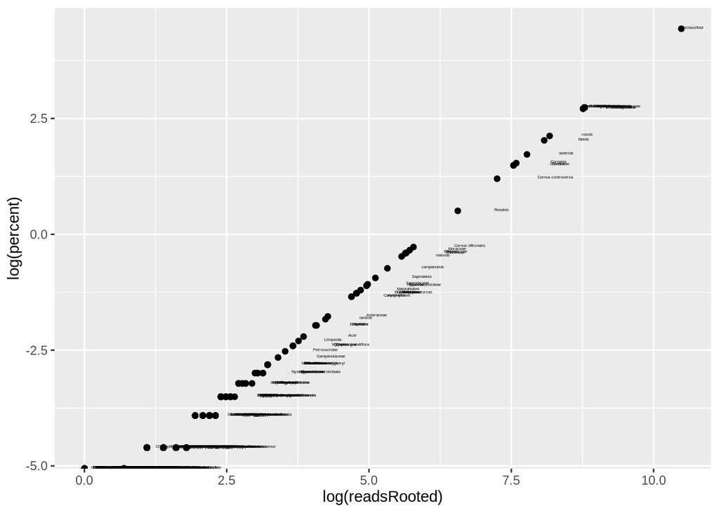

```r
ggplot(data=kreport, aes(x=log(readsRooted), y=log(percent))) +
  geom_point() +
  geom_text(aes(label=sciName),hjust=0, vjust=0, size=1)
```

# Homework

For next class: Using files for barcode10, barcode11, barcode12, or none.fastq, create a graph showing the read counts for the Kraken output based on the entire ‘nt’ database and one based on the plastid custom database. Post to #plots and discuss any differences.